# Experiment Report for Shota

## 5 Bayesian Models

Table 3: Bayesian Model specifications for Experiment 1.

| Parameter | Specification |
| --- | --- |
| **Family** | lognormal() |
| **Iterations** | 2000 (1000 warmup) |
| **Chains** | 4 |
| **Inits** | 0 |
| **Formula** | bf(duration ~ 1 + verb_type * sem_type + l_trial + (1 + verb_type * sem_type \| subject_id) + (1 + verb_type * sem_type \| head)) |

Table 4: Contrasts used in the Bayesian model.

| **Predictors** | `+0.5` | `-0.5` |
| --- | --- | --- |
| **Verb-Type** | Unaccusative | Unergative |
| **Semantic Relatedness** | Related | Unrelated |

```r
mprep_fun <- function(df) {
    df$verb_type %<>% as.factor()

    contrasts(df$verb_type) <- c(0.5, -0.5)
    contrasts(df$sem_type) <- c(0.5, -0.5)
    df$l_trial <- log(df$trial_no)

    df
}

memploy_fun <- function(df, prefix = "", iter = 2000, warmup = 1000, type="onset") {
    rt_priors <- c(
        set_prior("normal(6,1.5)", class = "Intercept"),
        set_prior("normal(0,1)", class = "b"),
        set_prior("cauchy(0,1)", class = "sd"),
        set_prior("cauchy(0,1)", class = "sigma"),
        set_prior("lkj(2)", class = "cor")
    )

    myformula <- bf(duration ~ 1 + verb_type * sem_type + l_trial +
        (1 + verb_type * sem_type | subject_id) +
        (1 + verb_type * sem_type | head))

    set.seed(42)
    m_onset <- brm(
        formula = myformula, data = df,
        family = lognormal(),
        prior = rt_priors,
        chains = 4, cores = 4, iter = iter, warmup = warmup,
        file = p(paste0("fits/m", prefix, "_", type))
    )
}



add_lines <- function(x_adjust, y_label, model, above = T, verbose = T) {
    if (above) {
        sign <- ">"
    } else {
        sign <- "<"
    }
    tmp_prob <- round(h_test(model, y_label, above), 2)
    if (verbose) {
        if (tmp_prob == 1) {
            tmp_label <- paste0("P(\u03b8", sign, "0) > 0.99")
        } else if (tmp_prob == 0) {
            tmp_label <- paste0("P(\u03b8", sign, "0) < 0.01")
        } else {
            tmp_label <- paste0("P(\u03b8", sign, "0) = ", tmp_prob)
        }
    } else {
        if (tmp_prob == 1) {
            tmp_label <- "[>0.99]"
        } else if (tmp_prob == 0) {
            tmp_label <- "[<0.01]"
        } else {
            tmp_label <- paste0("[", tmp_prob, "]")
        }
    }

    annotate("text",
        x = x_adjust, y = paste0("b_", y_label), hjust = -0.08,
        label = tmp_label, family = "Palatino",
        size = 3, color = "black"
    )
}

h_test <- function(model, parameter, above = T) {
  if (above) {
    as.numeric((hypothesis(model, paste0(parameter, " > 0"))$hypothesis["Post.Prob"]))
  } else {
    as.numeric((hypothesis(model, paste0(parameter, " < 0"))$hypothesis["Post.Prob"]))
  }
}
```

```r
full_onset <- full_onset |> mprep_fun()
m_onset <- full_onset |> memploy_fun()
```

Table 5: Posterior values and credible interval

```
Summary of Posterior Distribution

Parameter   |    Median |         89% CI |     pd
-------------------------------------------------
Intercept   |      7.22 | [ 7.16,  7.28] |   100%
Verb Type   |      0.02 | [ 0.00,  0.05] | 92.12%
Relatedness |  9.99e-03 | [-0.01,  0.03] | 78.65%
log(trial)  |     -0.05 | [-0.06, -0.04] |   100%
Interaction | -3.95e-03 | [-0.04,  0.04] | 56.55%
```

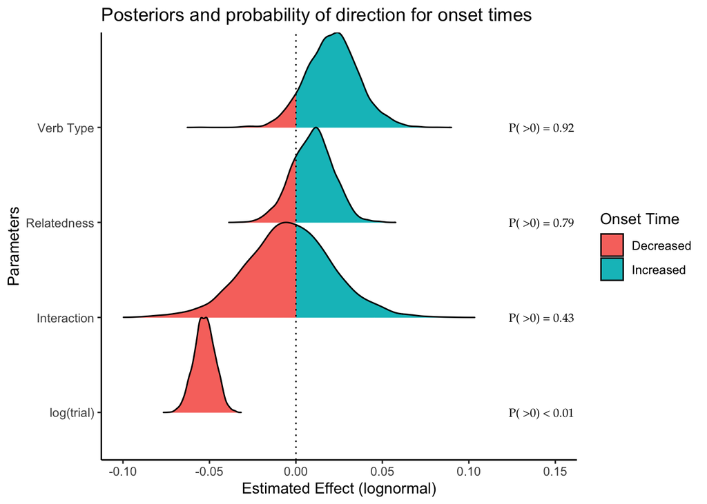

Figure 3: The posterior distributions of our model for **onset** times and probability of direction.

```r
full_pv <- full_pv |> mprep_fun()
m_pv <-full_pv |> memploy_fun(type = "pv")
```

Table 6: Posterior values and credible interval for the **preverb time** model

```
Summary of Posterior Distribution

Parameter   |    Median |         89% CI |     pd
-------------------------------------------------
Intercept   |      6.80 | [ 6.73,  6.87] |   100%
Verb Type   |      0.04 | [-0.04,  0.12] | 80.97%
Relatedness |  9.40e-04 | [-0.02,  0.03] | 52.60%
log(trial)  |     -0.02 | [-0.04, -0.01] |   100%
Interaction | -9.68e-03 | [-0.06,  0.04] | 63.70%
```

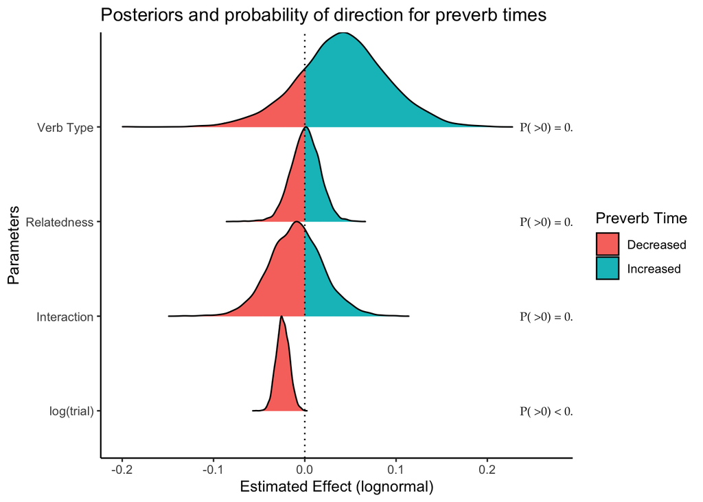

Figure 4: The posterior distributions of our model for **preverb** times and probability of direction.

## 6 Trial-no Filtered results

- The same specifications have been used in this experiments.
- Population level estimates for **the preverbal model for the first half** are reported in Table 7
- **The preverbal model for the first half** is visualized along with probability of direction in Figure 5
- Population level estimates for **the preverbal model for the second half** are reported in Table 8
- **The preverbal model for the second half** is visualized along with probability of direction in Figure 6

```r
filter_fun <- function(df, operator, trial_number ) {
  # Create a dynamic filter expression based on the operator
  filter_expr <- rlang::parse_expr(paste0("trial_no ", operator, " ", trial_number))
  # Filter the dataset using the dynamic filter expression
  df <- df %>% filter(!!filter_expr)
}
```

```r
m_fhalf_pv <- full_pv |> filter_fun( "<", 25) |>  memploy_fun(type = "pv", prefix = "firsthalf")

m_shalf_pv <- full_pv |> filter_fun( ">", 24)  |>  memploy_fun(type = "pv", prefix = "secondhalf")
```

### 6.1 First half of the experiment

- First thing to notice is that trial number effect is neutralized.
- Secondly, we have a suggestive positive maineffect of verb type, meaning that participants slowed down with unaccusative verbs preverbally. The median value of this effect is 53.81 The range of the effect however is surprisingly large: [-34.16,218.64].
- We also find a positive interaction, suggesting that people slowed down even more with related attractors. The median value of this effect is 42.7 The range of the effect however is surprisingly large: [-17.08,165.35].

Table 7: Posterior values and credible interval for the **preverb time** model of **the first half of the experiment**

```
Summary of Posterior Distribution

Parameter   |    Median |        89% CI |     pd
------------------------------------------------
Intercept   |      6.76 | [ 6.68, 6.83] |   100%
Verb Type   |      0.06 | [-0.04, 0.17] | 84.28%
Relatedness | -9.83e-03 | [-0.05, 0.03] | 66.53%
log(trial)  | -1.74e-03 | [-0.02, 0.02] | 55.67%
Interaction |      0.05 | [-0.02, 0.12] | 88.08%
```

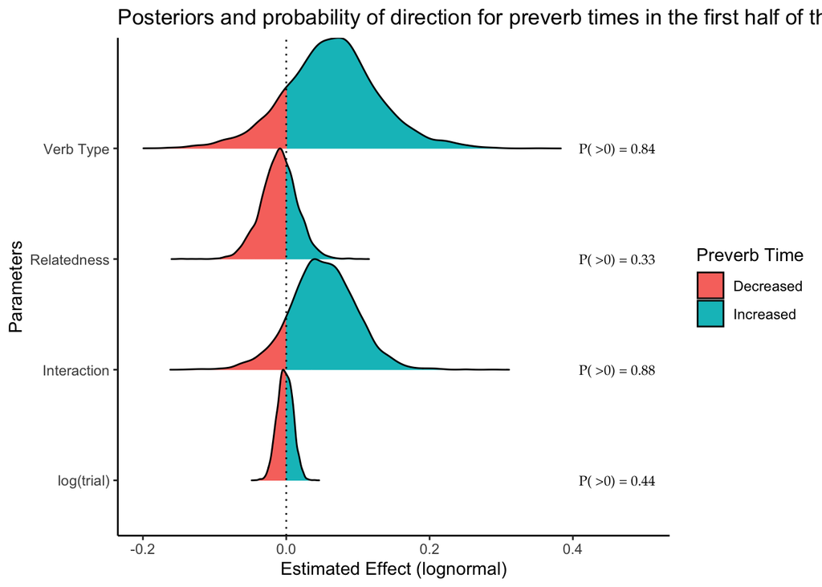

Figure 5: The posterior distributions of our model for **preverb** times and probability of direction for **the first half of the experiment**.

### 6.2 Second half of the experiment

Table 8: Posterior values and credible interval for the **preverb time** model of **the second half of the experiment**

```
Summary of Posterior Distribution

Parameter   |   Median |        89% CI |     pd
-----------------------------------------------
Intercept   |     6.91 | [ 6.64, 7.17] |   100%
Verb Type   |     0.02 | [-0.04, 0.09] | 72.52%
Relatedness | 3.68e-03 | [-0.03, 0.04] | 57.50%
log(trial)  |    -0.06 | [-0.13, 0.01] | 90.28%
Interaction |    -0.07 | [-0.15, 0.01] | 91.40%
```

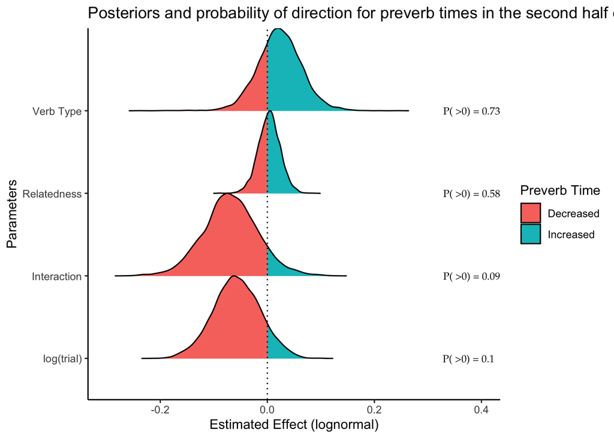

Figure 6: The posterior distributions of our model for **preverb** times and probability of direction for **the second half of the experiment**.

## References

Cousineau, Denis. 2005. “Confidence Intervals in Within-Subject Designs: A Simpler Solution to Loftus and Masson’s Method.” *Tutorials in Quantitative Methods for Psychology* 1 (1): 42–45. https://doi.org/10.20982/tqmp.01.1.p042.

Momma, Shota, and Victor S Ferreira. 2019. “Beyond Linear Order: The Role of Argument Structure in Speaking.” *Cognitive Psychology* 114: 101228.

Morey, Richard D. 2008. “Confidence Intervals from Normalized Data: A Correction to Cousineau (2005).” *Reason* 4 (2): 61–64. https://doi.org/10.20982/tqmp.04.2.p061.